# Coursework Report

*N* removed NAs: 3

*N* removed typo: 1

*N* removed <18: 21

*N* total clean: 126

| Group | *N* | *M*<sub>age</sub> | *M*<sub>rating</sub> |
| --- | --- | --- | --- |
| Control | 61 | 20.7 | 5.79 |
| Experim | 65 | 20.7 | 7.05 |

**Main analysis results**

*t*(124) = -9.23, *p* < .001

[interactive chart not shown]

[figure not shown]

[interactive chart not shown]

# Coursework Report

Analysing Data, Spring 2020

# Methods

## Design

The conceptual hypothesis for this study is ‘Does colour influence attractiveness’. The variables that are measured are colour and attractiveness. Colour is the independent categorical variable. To operationalise this variable, participants saw one picture, out of a possible two pictures, in either a white frame (which was the control group) or a red frame (which is the experimental condition), these are the two levels of the variable. The dependent continuous variable in this study is the rating of attractiveness. To operationalise this variable rating scales were used. Three questions were asked to assess attractiveness. The first question was ‘How attractive do you think this person is?’, the second question was ‘How pleasant is this person to look at?’ and the last question was ‘If I were to meet the person in this picture face to face, I would think he is attractive’. The ratings of attractiveness were given on a scale of 1-9 and were averaged to get a composite score. The values on the scale from 1-9 show that the higher the rating is the more attractive the picture is perceived as being. The operationalised hypothesis is ‘Does viewing a different colour frame around an image of a moderately attractive man influence the mean ratings of his attractiveness’. To determine whether perceived attractiveness is influenced by the colour of the picture frame, a statistical analysis involving an independent-measures *t*-test will be performed.

# Results

I investigated if women found men more attractive when their picture was viewed in a red or white frame using an independent-measures *t*-test. Overall, the results of this analysis indicate that colour does affect attractiveness ratings as the mean for the experimental (red) condition was higher (*M* = 7.05)than the mean for the control (white) condition (*M* = 5.79). Therefore, the analysis demonstrated that there was a significant difference in the mean attractiveness ratings of the red vs white colour groups (*M*<sub>diff</sub> = -1.26, 95% CI [-1.53, -0.99], *t* (124) = -9.23, *p* = .0000000). Therefore, demonstrating the participants in the red condition rated the man as more attractive than those in the white condition, meaning the null hypothesis can be rejected and the alternative hypothesis can be accepted, even though it is a smaller difference than what was expected. Thus, supporting the hypothesis and demonstrating that colour does influence ratings of attractiveness.

Below is a table showing the descriptive statistics of the age of the particpants including the standard deviation and the mean. There is also a table showing the descriptive statistics of age by condition. Lastly, there is a graph showing the mean attractiveness rating for each condition.

```
## # A tibble: 2 x 5
##   GROUP         mean    sd   min   max
##   <fct>        <dbl> <dbl> <dbl> <dbl>
## 1 control       20.7  1.98    18    25
## 2 experimental  20.7  1.63    18    25
```

```
## # A tibble: 2 x 5
##   GROUP            n  perc mean_YEARS sd_YEARS
##   <fct>        <int> <dbl>      <dbl>    <dbl>
## 1 control         61 0.484       20.7     1.98
## 2 experimental    65 0.516       20.7     1.63
```

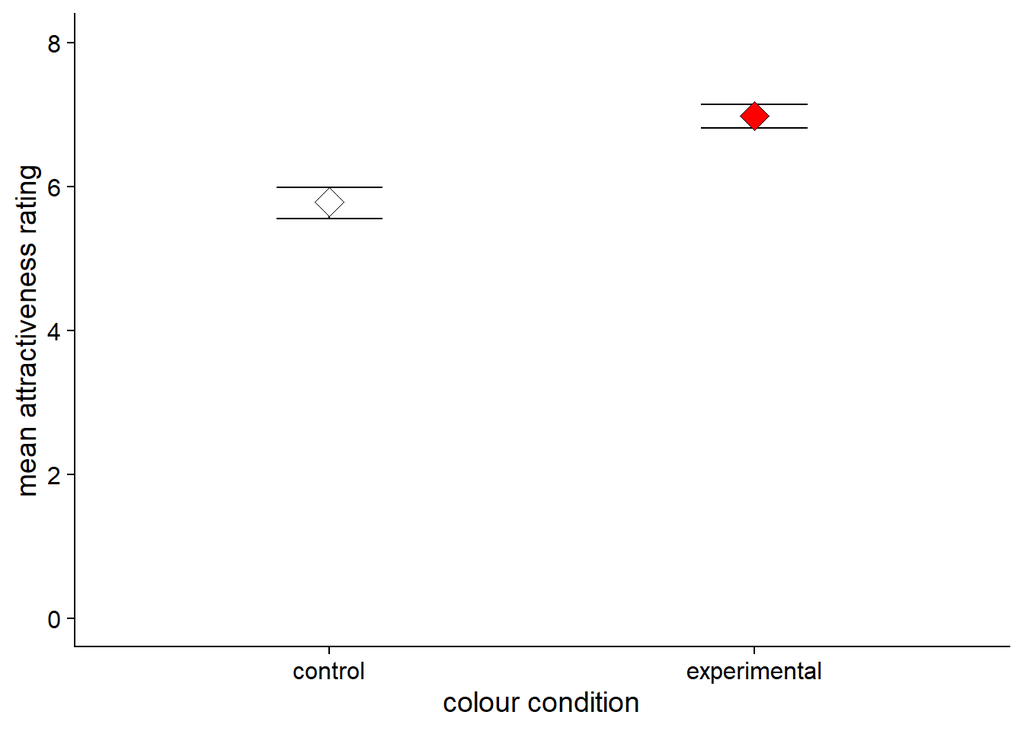

# Discussion

The experiment provides strong support for the idea that the colour red influences women’s attraction to men. The results show that even though the participants weren’t aware of the true focus of the study being the influence of colour on attraction this still had an effect on their response. The statistical analysis answered this question by demonstrating the fact that there is in fact a difference between perceived attractiveness depending on the colour of the photo frame. However, it is a smaller difference than might be expected. This research supports the original study conducted Elliot et al., 2010. The finding of this study suggests that colour influences attractiveness ratings without participants awareness. This suggests that the original study is replicable and the results are reliable and valid as they have been reproduced. Furthermore, the red effect (Elliot et al., 2010) is shown to be a valid influence on perceived attractiveness.

An analysis by Francis 2013 suggested that the claims made by Elliot et al., 2010 lack support as there is a publication bias involved in the reporting of Elliot’s findings. Francis used the Ioannidis and Trikalinos (2007b) statistical tests to test for publication bias. Francis suggested that some experiments with null findings weren’t reported or the ones that were reported weren’t properly run contributing to the rejection of the null hypothesis. Therefore, Francis concludes that the results should be considered non-scientific. This means that there may be less or unreliable support for the influence of colour on perceived attraction, casting doubt on the results of related studies. However, Elliot et al., (2013) claim their research was replicated by several independent investigators supporting its reliability. They claim that even though their research was underpowered, a replication by S. C. Roberts et al., (2010) provides further support with comparable effect sizes. Thus, supporting the Elliot et al., 2010 study and this replication. Hesslinger, Goldbach, and Carbon (2015) repeated the original Elliot et al., 2010 study with a larger sample size and did not find a significant effect of red on perceived attractiveness. Therefore, questioning the reliability of this research. As Hesslinger et al’s., (2015) replication doesn’t support the finding of the analysis I have run it suggests that there is uncertainty regarding the extent the colour red does effect attractiveness ratings. Also, it suggests that there needs to be more research done in this area to establish a firm conclusion. However, there are differences in Hesslinger et al’s research as German participants were tested not American participants that were used in the original study.

A further study by Peperkoorn, Roberts, & Pollet 2016 fail to support my findings. They found that women in white clothing were rated as more attractive than those in red. Thus, questioning the robustness of the red effect in human mate preferences. However, as the study required men to rate the attractiveness of women and the research, I conducted required the opposite, a direct comparison and conclusion on the basis of the findings of these two different methods cannot be drawn.

Problems regarding the design of the study can cause unreliable findings to occur. Because the design was an independent measure design it can cause individual differences to occur. Therefore, it is not possible to conclude that colour effects attractiveness ratings as this may be individual differences in regards to the photograph used. Therefore, it questions the reliability and generalisability of my findings, suggesting further research is needed. Furthermore, other factors such as cultural norms and mood of the participants on the day of testing can influence the perceived attractiveness of the men in the photos.

As there are some questions regarding the validity of the results of the red effect, further research will need to be conducted. To overcome the possibility of publication bias future research could employ the statistical analysis Ioannidis and Trikalinos (2007b). Future researchers may also want to use a different way of assessing perceived attractiveness. This is because the face-valid items used (Elliot et al., 2010) may be interpreted by participants differently. Furthermore, there are differences in the way individuals rat attractiveness. Therefore, as well as this method, further research could employ additional rating scales such as a Likert scale (Likert 1932). This would overcome this problem because it would give a more extensive representation of participants views on what constitutes attraction. There could also be more research into whether this effect occurs for men as well as women.

To conclude, on the basis of the results of this study and previous research, the red effect does seem to have an effect on perceived attractiveness although it is not as substantial an effect as what was hypothesised. I believe that red has an effect on ratings of attraction because red is associated with love and lust. Furthermore, it is also linked to high status males in a number of primates such as the mandrill and other species of baboon. Overall, this research supports the hypothesis that the colour red effects perceived attraction as the statistical analysis performed here has shown that red does have an influence. This suggests that the colour red is more than just a colour and can be used as a subtle form of communication, perhaps subconsciously, to help acquire a mate.

# References

Elliot, A. J., (2010). Red, Rank, and Romance in Women Viewing Men. Journal of Experimental Psychology: General, Vol. 139, (No. 3), 399-417. DOI: 10.1037/a0019689

Francis, G. (2013). Publication Bias in “Red, Rank, and Romance in Viewing Women and Men” by Elliot et al. (2010). Journal of Experimental Psychology: General, Vol. 142 (No. 1), 292-296. DOI: 10.1037/a0027923

Elliot, A. J., & Maier, M. A. (2013). The Red-Attractiveness Effect, Applying the Ioannidis and Trikalinos (2007b) Test, and the Broader Scientific Context: A Reply to Francis (2013). Journal of Experimental Psychology: General, Vol. 142 (No. 1), 297-300. DOI: 10.1037/a0029592

Hesslinger, V.M., Goldbach, L. & Carbon, C. (2015). Men in red: A reexamination of the red-attractiveness effect. Psychon Bull Rev 22, 1142–1148. https://doi.org/10.3758/s13423-015-0866-8

Peperkoorn, L.S., Roberts, S.C., Pollet, T.V. (2016). Revisiting the Red Effect on Attractiveness and Sexual Receptivity: No Effect of the Color Red on Human Mate Preferences. Evolutionary Psychology, Vol. 14 (No. 4). https://doi.org/10.1177/1474704916673841